# Exercises Laboratory Session 01

Nicola Zomer

27 March, 2022

```r
# tidyverse
library(ggplot2)
library(readr)
library(tibble)
library(glue)

# others
library(latex2exp)
library(scales)
library(kableExtra)
```

# Exercise 1 - Vectors and data frames

```r
df_lakes <- read.csv("../../data/lochs_of_Scotland.csv", header=TRUE, sep=",")
df_lakes %>%
  kbl() %>%
  kable_styling()
```

| Loch | Volume.km.3. | Volume.mi.3. | Area.km.2. | Area.mi.2. | Length.km. | Length.mi. | Max..depth.m. | Max..depth.ft. | Mean.depth.m. | Mean.depth.ft. |
| --- | --- | --- | --- | --- | --- | --- | --- | --- | --- | --- |
| Loch Ness | 7.45 | 1.790 | 56.0 | 22.0 | 36.2 | 22.5 | 227 | 745 | 132.0 | 433 |
| Loch Lomond | 2.60 | 0.620 | 71.0 | 27.0 | 36.0 | 22.0 | 190 | 620 | 37.0 | 121 |
| Loch Morar | 2.30 | 0.550 | 26.7 | 10.3 | 18.8 | 11.7 | 310 | 1020 | 87.0 | 285 |
| Loch Tay | 1.60 | 0.380 | 26.4 | 10.2 | 23.0 | 14.0 | 150 | 490 | 60.6 | 199 |
| Loch Awe | 1.20 | 0.290 | 39.0 | 15.0 | 41.0 | 25.0 | 94 | 308 | 32.0 | 105 |
| Loch Maree | 1.09 | 0.260 | 28.6 | 11.0 | 20.0 | 12.0 | 114 | 374 | 38.0 | 125 |
| Loch Ericht | 1.08 | 0.260 | 18.6 | 7.2 | 23.0 | 14.0 | 156 | 512 | 57.6 | 189 |
| Loch Lochy | 1.07 | 0.260 | 16.0 | 6.2 | 16.0 | 9.9 | 162 | 531 | 70.0 | 230 |
| Loch Rannoch | 0.97 | 0.230 | 19.0 | 7.3 | 15.7 | 9.8 | 134 | 440 | 51.0 | 167 |
| Loch Shiel | 0.79 | 0.190 | 19.5 | 7.5 | 28.0 | 17.0 | 128 | 420 | 40.0 | 130 |
| Loch Katrine | 0.77 | 0.180 | 12.4 | 4.8 | 12.9 | 8.0 | 151 | 495 | 43.4 | 142 |
| Loch Arkaig | 0.75 | 0.180 | 16.0 | 6.2 | 19.3 | 12.0 | 109 | 358 | 46.5 | 153 |
| Loch Shin | 0.35 | 0.084 | 22.5 | 8.7 | 27.8 | 17.3 | 49 | 161 | 15.5 | 51 |

```r
# Remove columns not containing volume or area and in [mi]
df_lakes <- df_lakes[, c(1, 2, 4)]

# Rename the columns
colnames(df_lakes) <- c('Loch', 'Volume', 'Area')
df_lakes %>%
  kbl() %>%
  kable_styling()
```

| Loch | Volume | Area |
| --- | --- | --- |
| Loch Ness | 7.45 | 56.0 |
| Loch Lomond | 2.60 | 71.0 |
| Loch Morar | 2.30 | 26.7 |
| Loch Tay | 1.60 | 26.4 |
| Loch Awe | 1.20 | 39.0 |
| Loch Maree | 1.09 | 28.6 |
| Loch Ericht | 1.08 | 18.6 |
| Loch Lochy | 1.07 | 16.0 |
| Loch Rannoch | 0.97 | 19.0 |
| Loch Shiel | 0.79 | 19.5 |
| Loch Katrine | 0.77 | 12.4 |
| Loch Arkaig | 0.75 | 16.0 |
| Loch Shin | 0.35 | 22.5 |

## 1. Evaluate the highest and lowest volume and area lake

```r
# indices
idx_max_vol <- which.max(df_lakes$Volume)
idx_min_vol <- which.min(df_lakes$Volume)
idx_max_area <- which.max(df_lakes$Area)
idx_min_area <- which.min(df_lakes$Area)

# results

cat(
  'Highest volume lake:', df_lakes$Loch[idx_max_vol], ', with volume ', df_lakes$Volume[idx_max_vol], 'km^3\n',
  'Lowest volume lake:', df_lakes$Loch[idx_min_vol], ', with volume ', df_lakes$Volume[idx_min_vol], 'km^3\n',
  'Highest area lake:', df_lakes$Loch[idx_max_area], ', with area ', df_lakes$Area[idx_max_area], 'km^2\n',
  'Lowest area lake:', df_lakes$Loch[idx_min_area], ', with area ', df_lakes$Area[idx_min_area], 'km^2'

  )
```

```
## Highest volume lake: Loch Ness , with volume  7.45 km^3
##  Lowest volume lake: Loch Shin , with volume  0.35 km^3
##  Highest area lake: Loch Lomond , with area  71 km^2
##  Lowest area lake: Loch Katrine , with area  12.4 km^2
```

## 2. Order the frame with respect to the area and determine the two largest area lakes

Ordered dataframe:

```r
lakes_byarea <- df_lakes[order(df_lakes$Area, decreasing=TRUE), ]
lakes_byarea %>%
  kbl() %>%
  kable_styling()
```

|  | Loch | Volume | Area |
| --- | --- | --- | --- |
| 2 | Loch Lomond | 2.60 | 71.0 |
| 1 | Loch Ness | 7.45 | 56.0 |
| 5 | Loch Awe | 1.20 | 39.0 |
| 6 | Loch Maree | 1.09 | 28.6 |
| 3 | Loch Morar | 2.30 | 26.7 |
| 4 | Loch Tay | 1.60 | 26.4 |
| 13 | Loch Shin | 0.35 | 22.5 |
| 10 | Loch Shiel | 0.79 | 19.5 |
| 9 | Loch Rannoch | 0.97 | 19.0 |
| 7 | Loch Ericht | 1.08 | 18.6 |
| 8 | Loch Lochy | 1.07 | 16.0 |
| 12 | Loch Arkaig | 0.75 | 16.0 |
| 11 | Loch Katrine | 0.77 | 12.4 |

```r
largest_area_2 = lakes_byarea$Loch[1:2]

glue('2 largest area lakes: {largest_area_2[1]} and {largest_area_2[2]}')
```

```
## 2 largest area lakes: Loch Lomond and Loch Ness
```

## 3. By summing up the areas occupied by the lakes, determine the area of Scotland covered by water

```r
area_water <- sum(df_lakes$Area)
glue('Area of Scotland covered by water: {area_water} km^2')
```

```
## Area of Scotland covered by water: 371.7 km^2
```

Reference and data: https://en.wikipedia.org/wiki/List_of_lochs_of_Scotland

# Exercise 2 - Crude Oil Production

## 1. Write R code that is able to read the file and import it in a data frame structure

The last column of the data frame contains data on crude oil prices from 1861 to 2020, measured in US dollars per barrel.

```r
df_oilprices <- read.csv("../../data/crude-oil-prices.csv", header=TRUE, sep=",")
colnames(df_oilprices) <- c(names(df_oilprices[1:3]), 'Price')

str(df_oilprices)
```

```
## 'data.frame':    160 obs. of  4 variables:
##  $ Entity: chr  "World" "World" "World" "World" ...
##  $ Code  : chr  "OWID_WRL" "OWID_WRL" "OWID_WRL" "OWID_WRL" ...
##  $ Year  : int  1861 1862 1863 1864 1865 1866 1867 1868 1869 1870 ...
##  $ Price : num  0.49 1.05 3.15 8.06 6.59 3.74 2.41 3.63 3.64 3.86 ...
```

## 2. Produce a plot with the Oil price as a function of the year

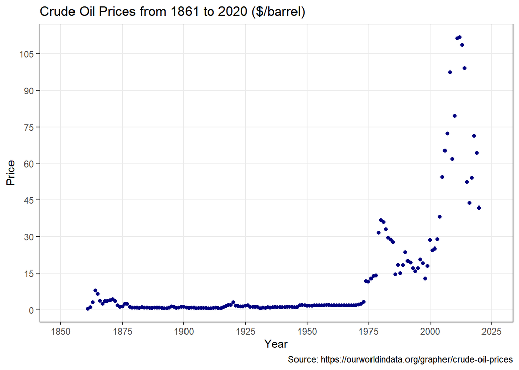

```r
gg <- ggplot(df_oilprices, aes(x=Year, y=Price))+
  geom_point(col='navyblue')+
  labs(title="Crude Oil Prices from 1861 to 2020 ($/barrel)",
       y="Price",
       x='Year',
       caption = "Source: https://ourworldindata.org/grapher/crude-oil-prices") +
  scale_y_continuous(
    breaks = seq(0, 120, 15),
    minor_breaks = NULL
  ) +
  scale_x_continuous(
    breaks = seq(1850, 2050, 25),
    minor_breaks = NULL,
    limits=c(1850, 2025)
  )+
  theme_bw()


plot(gg)
```

## 3. Which is the highest price in history ? When did it occur ?

```r
highest_price <- max(df_oilprices$Price)
highest_price_year <- df_oilprices$Year[which.max(df_oilprices$Price)]

glue('Highest price in hystory: {format(highest_price, digits=5)} $/barrel.\n
  It occured in {highest_price_year}.')
```

```
## Highest price in hystory: 111.67 $/barrel.
##
## It occured in 2012.
```

## 4. Plot the derivative of the curve, simply evaluated with the fi nite difference formula

$$\frac{\partial price}{\partial year} = price_{j+1}-price{j}$$

```r
prices <- df_oilprices$Price
years <- df_oilprices$Year
derivatives <- prices[2:length(prices)]-prices[1:length(prices)-1]

df_derivatives <- data.frame(years[1:length(years)-1], derivatives)
colnames(df_derivatives) <- c('Year', 'Derivative')

str(df_derivatives)
```

```
## 'data.frame':    159 obs. of  2 variables:
##  $ Year      : int  1861 1862 1863 1864 1865 1866 1867 1868 1869 1870 ...
##  $ Derivative: num  0.56 2.1 4.91 -1.47 -2.85 ...
```

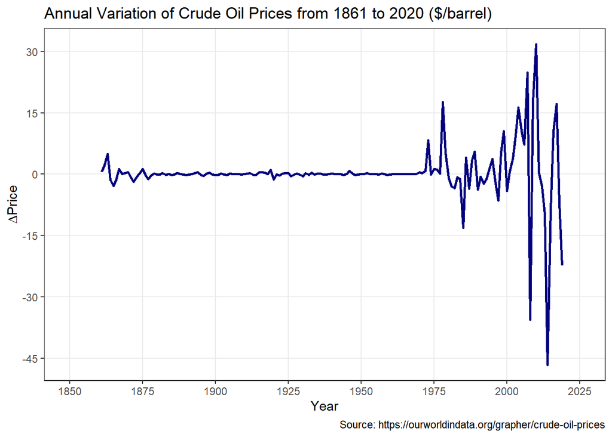

```r
gg <- ggplot(df_derivatives, aes(x=Year, y=Derivative))+
  geom_line(col='navyblue', size=1) +
  labs(title="Annual Variation of Crude Oil Prices from 1861 to 2020 ($/barrel)",
       y=TeX("$\\Delta$Price"),
       x='Year',
       caption = "Source: https://ourworldindata.org/grapher/crude-oil-prices") +
  scale_x_continuous(
    breaks = seq(1850, 2050, 25),
    minor_breaks = NULL,
    limits=c(1850, 2025)
  ) +
  scale_y_continuous(
    breaks = seq(-45, 45, 15),
    minor_breaks = NULL,
  )+
  theme_bw()

plot(gg)
```

Reference and data: https://ourworldindata.org/grapher/crude-oil-prices

# Exercise 3 - World Coal Production

## 1. Write R code that is able to read the file and import it in a tibble structure

```r
coal_prod <- read_csv("../../data/coal-production-by-country.csv", col_names=TRUE)
colnames(coal_prod) <- c(names(coal_prod[1:3]), 'Production')

kable(head(coal_prod)) %>%
  kable_styling()
```

| Entity | Code | Year | Production |
| --- | --- | --- | --- |
| Afghanistan | AFG | 1900 | 0 |
| Afghanistan | AFG | 1901 | 0 |
| Afghanistan | AFG | 1902 | 0 |
| Afghanistan | AFG | 1903 | 0 |
| Afghanistan | AFG | 1904 | 0 |
| Afghanistan | AFG | 1905 | 0 |

```r
is_tibble(coal_prod)
```

```
## [1] TRUE
```

## 2. Count the number of countries available in the file and produce a barplot with the number of entries for each country

```r
countries <- unique(coal_prod$Entity)
cat('Number of countries:', length(countries))
```

```
## Number of countries: 200
```

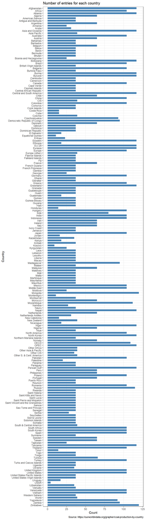

```r
gg <- ggplot(data=coal_prod, aes(x=Entity)) +
  geom_bar(stat = "count", width=0.7, fill="steelblue") +
  coord_flip() +
  scale_x_discrete(limits=rev) +
  labs(title="Number of entries for each country",
       x="Country",
       y="Count",
       caption = "Source: https://ourworldindata.org/grapher/coal-production-by-country") +
  theme_bw()

gg
```

For the following items select only the years
$$\geq$$
1970.

## 3. Selecting only the year after 1970, determine the total integrated production for each country and print the top 5 countries with highest coal productions

```r
# select only the years after 1970
coal_prod_1970 <- coal_prod[coal_prod['Year']>1970, ]

# total integrated production for each country
int_prod_1970 <- aggregate(coal_prod_1970$Production, by=list(coal_prod_1970$Entity), FUN=sum)
colnames(int_prod_1970) <- c('Country', 'IntProd')

# top 5 countries
int_prod_1970[order(int_prod_1970$IntProd, decreasing = TRUE)[1:5], ] %>%
  kbl() %>%
  kable_styling()
```

|  | Country | IntProd |
| --- | --- | --- |
| 176 | World | 1260113.2 |
| 9 | Asia Pacific | 690240.5 |
| 8 | Asia and Oceania | 682343.9 |
| 32 | China | 459564.6 |
| 120 | OECD | 428754.2 |

## 4. For the 5 top Countries, create a plot of production as a function of time

```r
# reduced dataframe
sel_countries <- c('World', 'Asia Pacific', 'Asia and Oceania', 'China', 'OECD')
df_sel <- coal_prod_1970[coal_prod_1970$Entity %in% sel_countries, ]

# inspect it
str(df_sel)
```

```
## tibble [201 x 4] (S3: tbl_df/tbl/data.frame)
##  $ Entity    : chr [1:201] "Asia Pacific" "Asia Pacific" "Asia Pacific" "Asia Pacific" ...
##  $ Code      : chr [1:201] NA NA NA NA ...
##  $ Year      : num [1:201] 1981 1982 1983 1984 1985 ...
##  $ Production: num [1:201] 5794 6088 6441 6973 7714 ...
```

```r
cat('\nEntities in df_sel:', unique(df_sel$Entity))
```

```
##
## Entities in df_sel: Asia Pacific Asia and Oceania China OECD World
```

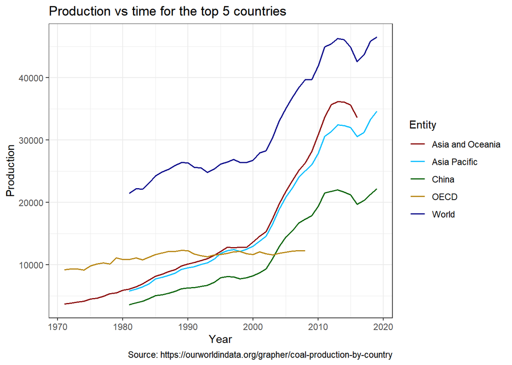

```r
colors <- c('darkred', 'deepskyblue', 'darkgreen', 'darkgoldenrod', 'darkblue')

ggplot(df_sel, aes(x = Year, y = Production)) +
  geom_line(aes(color = Entity), size=0.6) +
  scale_color_manual(values = colors)+
  labs(title="Production vs time for the top 5 countries",
       caption = "Source: https://ourworldindata.org/grapher/coal-production-by-country") +
  theme_bw()
```

## 5. Generate a plot with the cumulative sum of the World’s coal production over the years

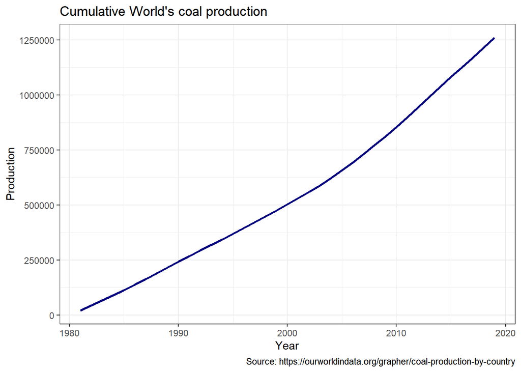

```r
world_cum <- cumsum(coal_prod_1970$Production[coal_prod_1970$Entity=='World'])
years <- coal_prod_1970$Year[coal_prod_1970$Entity=='World']

ggplot() +
  geom_line(aes(x=years, y=world_cum), col='navyblue', size=1) +
  labs(title="Cumulative World's coal production",
       x="Year",
       y="Production",
       caption = "Source: https://ourworldindata.org/grapher/coal-production-by-country") +
  theme_bw()
```

Reference and data: https://ourworldindata.org/grapher/coal-production-by-country

# Exercise 4 - Covid19 Vaccine data

## File ‘vaccinations-by-manufacturer.csv’

Data: https://github.com/owid/covid-19-data/blob/master/public/data/vaccinations/vaccinations-by-manufacturer.csv

## File ‘vaccinations.csv’

Data: https://github.com/owid/covid-19-data/blob/master/public/data/vaccinations/vaccinations.csv